# time series analysis

Laura Menicacci

2023-12-05

# Exploration Break detection

- Controls: GDP and population
- Data samples: Y02 (all ccmts), Y02E (energy), solar, wind, batteries
- Total countries covered: 196

## Prepare data

- Aggregate 3 types of solar techs into 1
- Add 0 values for missing years

## Restrict country sample

1. Group by country and technology class
2. Create statistical info: median, q25, mean, q75, max sd

Example of how the dataset looks like:

- a lot of zeros!

  | ISO | tech | median | q25 | mean | q75 | max | sd |
  | --- | --- | --- | --- | --- | --- | --- | --- |
  | AFG | Climate change mitigation | 0.0 | 0 | 0.0376452 | 0.0000 | 1.000 | 0.1811038 |
  | AFG | Climate change mitigation technologies related to energy generation, transmission or distribution | 0.0 | 0 | 0.0376452 | 0.0000 | 1.000 | 0.1811038 |
  | AFG | Solar energy | 0.0 | 0 | 0.0053871 | 0.0000 | 0.167 | 0.0299941 |
  | AFG | Wind energy | 0.0 | 0 | 0.0000000 | 0.0000 | 0.000 | 0.0000000 |
  | AFG | Batteries | 0.0 | 0 | 0.0000000 | 0.0000 | 0.000 | 0.0000000 |
  | AGO | Climate change mitigation | 0.0 | 0 | 0.0161290 | 0.0000 | 0.500 | 0.0898027 |
  | AGO | Climate change mitigation technologies related to energy generation, transmission or distribution | 0.0 | 0 | 0.0161290 | 0.0000 | 0.500 | 0.0898027 |
  | AGO | Solar energy | 0.0 | 0 | 0.0161290 | 0.0000 | 0.500 | 0.0898027 |
  | AGO | Wind energy | 0.0 | 0 | 0.0161290 | 0.0000 | 0.500 | 0.0898027 |
  | AGO | Batteries | 0.0 | 0 | 0.0000000 | 0.0000 | 0.000 | 0.0000000 |
  | ALB | Climate change mitigation | 0.0 | 0 | 0.6913871 | 0.5000 | 4.983 | 1.3771277 |
  | ALB | Climate change mitigation technologies related to energy generation, transmission or distribution | 0.0 | 0 | 0.0725806 | 0.0000 | 1.000 | 0.2202250 |
  | ALB | Solar energy | 0.0 | 0 | 0.0000000 | 0.0000 | 0.000 | 0.0000000 |
  | ALB | Wind energy | 0.0 | 0 | 0.0000000 | 0.0000 | 0.000 | 0.0000000 |
  | ALB | Batteries | 0.0 | 0 | 0.0000000 | 0.0000 | 0.000 | 0.0000000 |
  | AND | Climate change mitigation | 0.0 | 0 | 0.1892258 | 0.2665 | 1.000 | 0.3408215 |
  | AND | Climate change mitigation technologies related to energy generation, transmission or distribution | 0.0 | 0 | 0.1505161 | 0.0000 | 1.000 | 0.3342888 |
  | AND | Solar energy | 0.0 | 0 | 0.0268710 | 0.0000 | 0.500 | 0.1062239 |
  | AND | Wind energy | 0.0 | 0 | 0.0214839 | 0.0000 | 0.333 | 0.0831604 |
  | AND | Batteries | 0.0 | 0 | 0.0000000 | 0.0000 | 0.000 | 0.0000000 |
  | ANT | Climate change mitigation | 0.5 | 0 | 0.7515806 | 1.0835 | 4.817 | 1.0175182 |
  | ANT | Climate change mitigation technologies related to energy generation, transmission or distribution | 0.0 | 0 | 0.1741613 | 0.0000 | 1.450 | 0.3949840 |
  | ANT | Solar energy | 0.0 | 0 | 0.0000000 | 0.0000 | 0.000 | 0.0000000 |
  | ANT | Wind energy | 0.0 | 0 | 0.0322581 | 0.0000 | 0.500 | 0.1248655 |
  | ANT | Batteries | 0.0 | 0 | 0.0214839 | 0.0000 | 0.333 | 0.0831604 |

Whole distribution of country means faceted by technology:

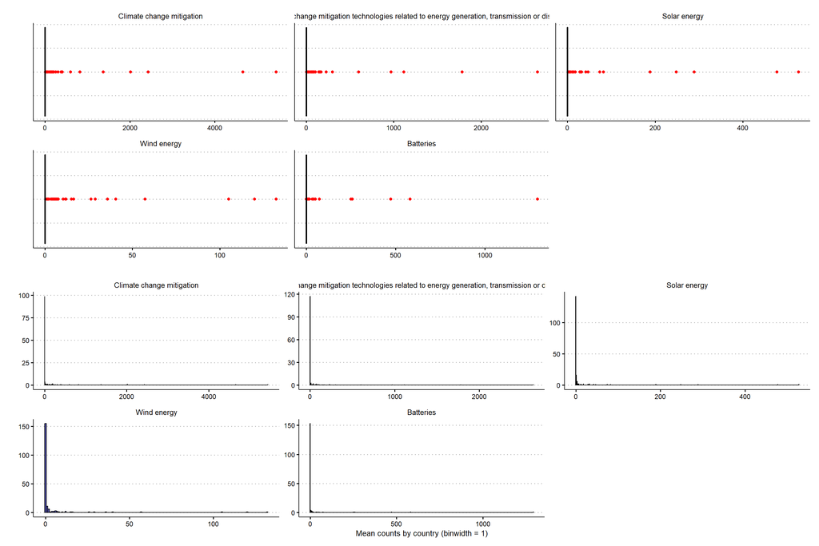

Divide distribution in quantiles and plot country 25th quantile faceted by technology:

- where to cut the distribution?
- vertical red line on the 30th quantile

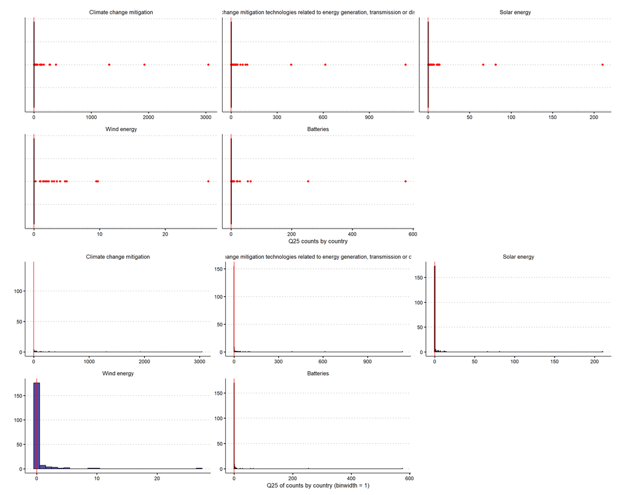

3. **Selection criteria**: for each q25 of country&tech, if it is less than 30th quantile of entire distribution of patent counts, drop
4. Total sample: 21 countries

Time series:

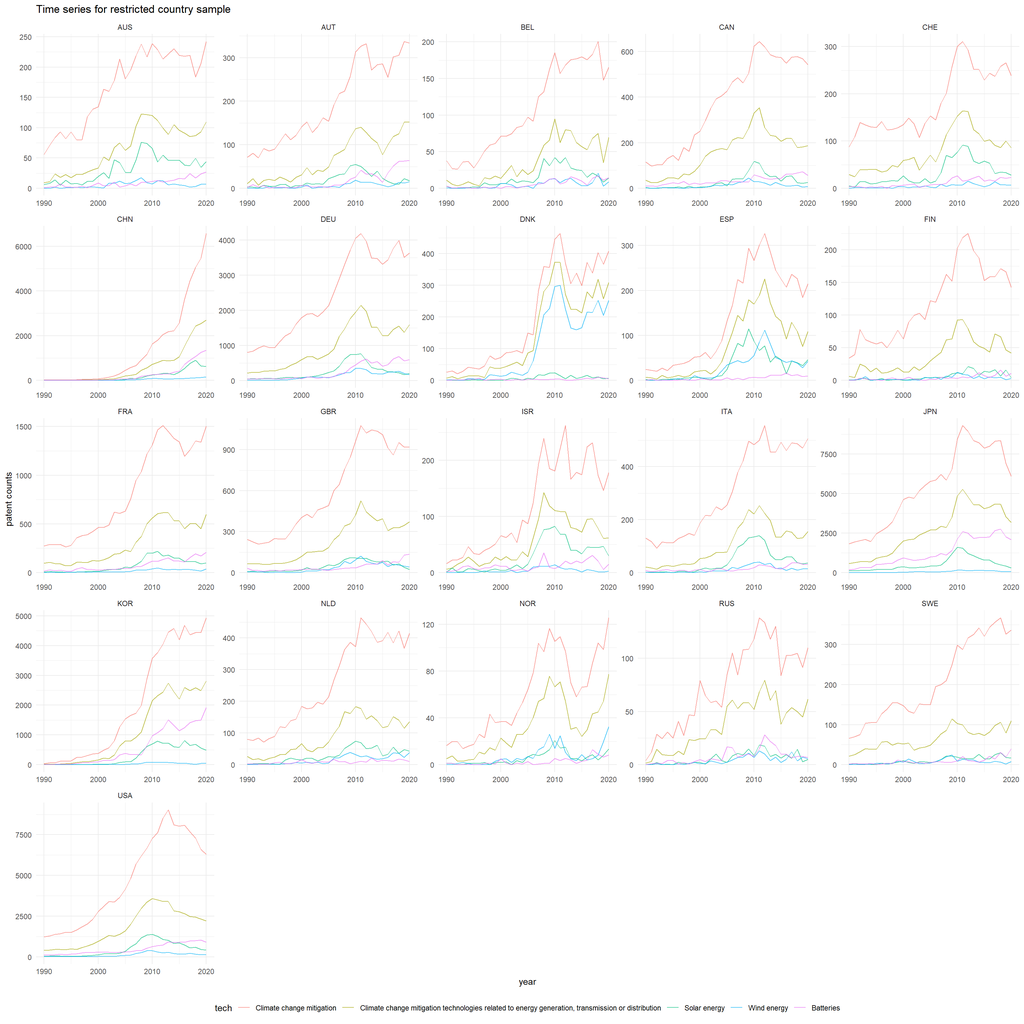

Reasons:

- I wanted to make sure that all countries in the sample had a decent distribution for all the technologies for the first run of the model
- Keep sample small to make it run faster
- Double-checked with **top 25 patenting countries**: they are almost the same except for *Brazil, India, Taiwan, Singapore*, which then were added for the second run

Check change in distribution:

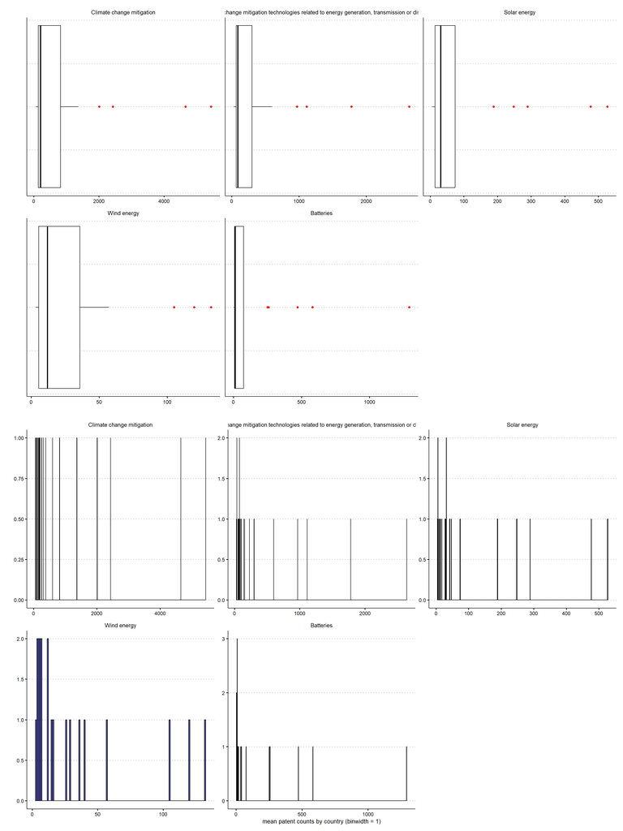

**Alternative: Select 25 top patenting countries by mean** - Check distribution of country means:

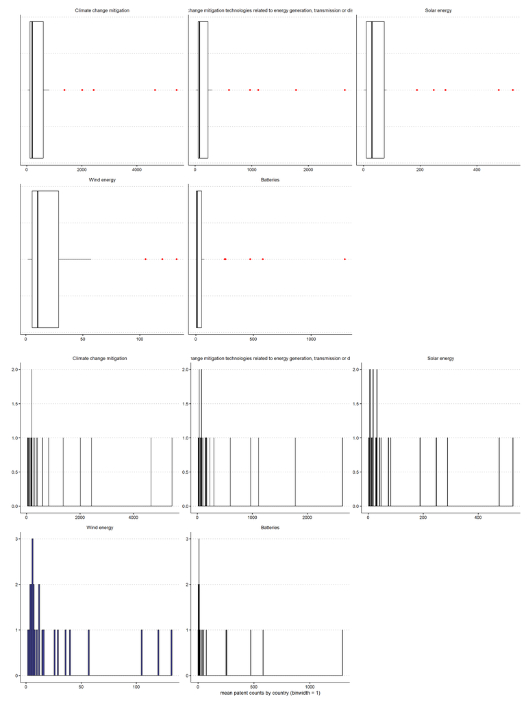

Select 50 top patenting countries (by mean) and check again distribution of country means:

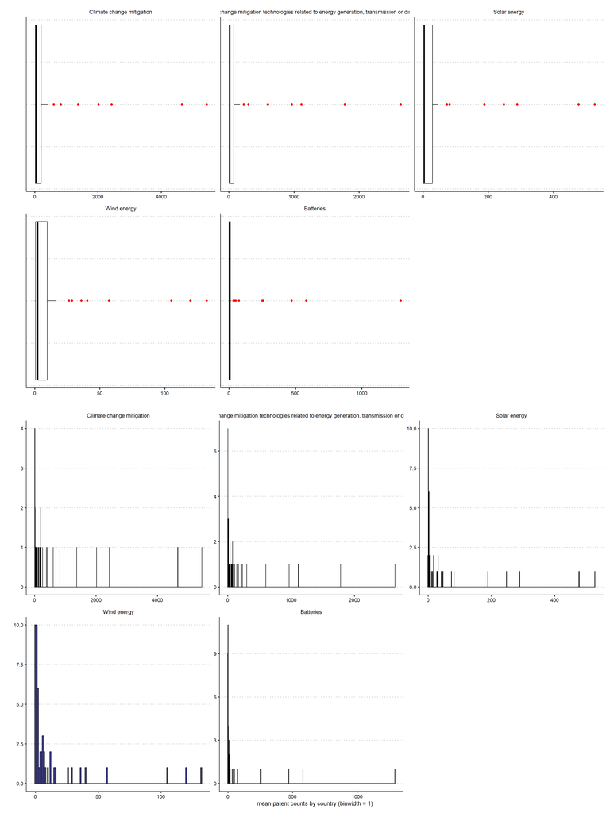

## Time series analysis

**Augmented Dickey-Fuller Test**

- Check for stationarity by technology
- Three types of tests

### CCMT

```r
adf_data_ccmt <- df3 %>% filter(tech == "Climate change mitigation")

adf_data_energy <- df3 %>% filter(tech == "Climate change mitigation technologies related to energy generation, transmission or distribution")

adf_data_batteries <- df3 %>% filter(tech == "Batteries")

adf_data_solar <- df3 %>% filter(tech == "Solar energy")

adf_data_wind <- df3 %>% filter(tech == "Wind energy")



summary(ur.df(y=adf_data_ccmt$count, type = "none",lags=1))
```

```
##
## ###############################################
## # Augmented Dickey-Fuller Test Unit Root Test #
## ###############################################
##
## Test regression none
##
##
## Call:
## lm(formula = z.diff ~ z.lag.1 - 1 + z.diff.lag)
##
## Residuals:
##     Min      1Q  Median      3Q     Max
## -6395.3    -1.8     3.1    18.0  2097.5
##
## Coefficients:
##             Estimate Std. Error t value Pr(>|t|)
## z.lag.1    -0.038071   0.006758  -5.634 2.09e-08 ***
## z.diff.lag  0.072801   0.025365   2.870  0.00416 **
## ---
## Signif. codes:  0 '***' 0.001 '**' 0.01 '*' 0.05 '.' 0.1 ' ' 1
##
## Residual standard error: 347.1 on 1546 degrees of freedom
## Multiple R-squared:  0.02295,    Adjusted R-squared:  0.02169
## F-statistic: 18.16 on 2 and 1546 DF,  p-value: 1.606e-08
##
##
## Value of test-statistic is: -5.6338
##
## Critical values for test statistics:
##       1pct  5pct 10pct
## tau1 -2.58 -1.95 -1.62
```

```r
summary(ur.df(y=adf_data_ccmt$count, type = "drift",lags=1))
```

```
##
## ###############################################
## # Augmented Dickey-Fuller Test Unit Root Test #
## ###############################################
##
## Test regression drift
##
##
## Call:
## lm(formula = z.diff ~ z.lag.1 + 1 + z.diff.lag)
##
## Residuals:
##     Min      1Q  Median      3Q     Max
## -6386.7   -19.4   -14.6     0.9  2107.0
##
## Coefficients:
##              Estimate Std. Error t value Pr(>|t|)
## (Intercept) 17.858667   9.308627   1.919  0.05523 .
## z.lag.1     -0.042474   0.007131  -5.956 3.19e-09 ***
## z.diff.lag   0.075001   0.025369   2.956  0.00316 **
## ---
## Signif. codes:  0 '***' 0.001 '**' 0.01 '*' 0.05 '.' 0.1 ' ' 1
##
## Residual standard error: 346.8 on 1545 degrees of freedom
## Multiple R-squared:  0.02527,    Adjusted R-squared:  0.02401
## F-statistic: 20.03 on 2 and 1545 DF,  p-value: 2.586e-09
##
##
## Value of test-statistic is: -5.9561 17.7375
##
## Critical values for test statistics:
##       1pct  5pct 10pct
## tau2 -3.43 -2.86 -2.57
## phi1  6.43  4.59  3.78
```

```r
summary(ur.df(y=adf_data_ccmt$count, type = "trend",lags=1))
```

```
##
## ###############################################
## # Augmented Dickey-Fuller Test Unit Root Test #
## ###############################################
##
## Test regression trend
##
##
## Call:
## lm(formula = z.diff ~ z.lag.1 + 1 + tt + z.diff.lag)
##
## Residuals:
##     Min      1Q  Median      3Q     Max
## -6385.1   -19.8   -14.7     1.1  2107.1
##
## Coefficients:
##              Estimate Std. Error t value Pr(>|t|)
## (Intercept) 15.603847  17.816131   0.876  0.38126
## z.lag.1     -0.042517   0.007139  -5.955 3.21e-09 ***
## tt           0.002931   0.019746   0.148  0.88201
## z.diff.lag   0.075032   0.025378   2.957  0.00316 **
## ---
## Signif. codes:  0 '***' 0.001 '**' 0.01 '*' 0.05 '.' 0.1 ' ' 1
##
## Residual standard error: 346.9 on 1544 degrees of freedom
## Multiple R-squared:  0.02529,    Adjusted R-squared:  0.02339
## F-statistic: 13.35 on 3 and 1544 DF,  p-value: 1.324e-08
##
##
## Value of test-statistic is: -5.9553 11.8249 17.7373
##
## Critical values for test statistics:
##       1pct  5pct 10pct
## tau3 -3.96 -3.41 -3.12
## phi2  6.09  4.68  4.03
## phi3  8.27  6.25  5.34
```

### ENERGY

```r
summary(ur.df(y=adf_data_energy$count, type = "none",lags=1))
```

```
##
## ###############################################
## # Augmented Dickey-Fuller Test Unit Root Test #
## ###############################################
##
## Test regression none
##
##
## Call:
## lm(formula = z.diff ~ z.lag.1 - 1 + z.diff.lag)
##
## Residuals:
##      Min       1Q   Median       3Q      Max
## -2983.03    -1.61     1.16     8.58  1399.99
##
## Coefficients:
##             Estimate Std. Error t value Pr(>|t|)
## z.lag.1    -0.041225   0.006863  -6.006 2.36e-09 ***
## z.diff.lag  0.116706   0.025259   4.620 4.15e-06 ***
## ---
## Signif. codes:  0 '***' 0.001 '**' 0.01 '*' 0.05 '.' 0.1 ' ' 1
##
## Residual standard error: 163.5 on 1546 degrees of freedom
## Multiple R-squared:  0.03183,    Adjusted R-squared:  0.03057
## F-statistic: 25.41 on 2 and 1546 DF,  p-value: 1.386e-11
##
##
## Value of test-statistic is: -6.0064
##
## Critical values for test statistics:
##       1pct  5pct 10pct
## tau1 -2.58 -1.95 -1.62
```

```r
summary(ur.df(y=adf_data_energy$count, type = "drift",lags=1))
```

```
##
## ###############################################
## # Augmented Dickey-Fuller Test Unit Root Test #
## ###############################################
##
## Test regression drift
##
##
## Call:
## lm(formula = z.diff ~ z.lag.1 + 1 + z.diff.lag)
##
## Residuals:
##      Min       1Q   Median       3Q      Max
## -2977.51    -9.83    -7.11     0.45  1404.82
##
## Coefficients:
##              Estimate Std. Error t value Pr(>|t|)
## (Intercept)  8.296721   4.356042   1.905    0.057 .
## z.lag.1     -0.045358   0.007193  -6.306 3.73e-10 ***
## z.diff.lag   0.118772   0.025261   4.702 2.81e-06 ***
## ---
## Signif. codes:  0 '***' 0.001 '**' 0.01 '*' 0.05 '.' 0.1 ' ' 1
##
## Residual standard error: 163.4 on 1545 degrees of freedom
## Multiple R-squared:  0.03409,    Adjusted R-squared:  0.03284
## F-statistic: 27.27 on 2 and 1545 DF,  p-value: 2.301e-12
##
##
## Value of test-statistic is: -6.306 19.883
##
## Critical values for test statistics:
##       1pct  5pct 10pct
## tau2 -3.43 -2.86 -2.57
## phi1  6.43  4.59  3.78
```

```r
summary(ur.df(y=adf_data_energy$count, type = "trend",lags=1))
```

```
##
## ###############################################
## # Augmented Dickey-Fuller Test Unit Root Test #
## ###############################################
##
## Test regression trend
##
##
## Call:
## lm(formula = z.diff ~ z.lag.1 + 1 + tt + z.diff.lag)
##
## Residuals:
##      Min       1Q   Median       3Q      Max
## -2977.46    -9.89    -7.05     0.62  1404.87
##
## Coefficients:
##              Estimate Std. Error t value Pr(>|t|)
## (Intercept)  7.506411   8.392136   0.894    0.371
## z.lag.1     -0.045383   0.007199  -6.304 3.77e-10 ***
## tt           0.001025   0.009301   0.110    0.912
## z.diff.lag   0.118790   0.025270   4.701 2.82e-06 ***
## ---
## Signif. codes:  0 '***' 0.001 '**' 0.01 '*' 0.05 '.' 0.1 ' ' 1
##
## Residual standard error: 163.5 on 1544 degrees of freedom
## Multiple R-squared:  0.0341, Adjusted R-squared:  0.03223
## F-statistic: 18.17 on 3 and 1544 DF,  p-value: 1.372e-11
##
##
## Value of test-statistic is: -6.3044 13.2509 19.8764
##
## Critical values for test statistics:
##       1pct  5pct 10pct
## tau3 -3.96 -3.41 -3.12
## phi2  6.09  4.68  4.03
## phi3  8.27  6.25  5.34
```

### SOLAR

```r
summary(ur.df(y=adf_data_solar$count, type = "none",lags=1))
```

```
##
## ###############################################
## # Augmented Dickey-Fuller Test Unit Root Test #
## ###############################################
##
## Test regression none
##
##
## Call:
## lm(formula = z.diff ~ z.lag.1 - 1 + z.diff.lag)
##
## Residuals:
##     Min      1Q  Median      3Q     Max
## -571.73   -1.36    0.05    3.54  361.37
##
## Coefficients:
##             Estimate Std. Error t value Pr(>|t|)
## z.lag.1    -0.048820   0.006196  -7.879 6.18e-15 ***
## z.diff.lag  0.392100   0.023396  16.759  < 2e-16 ***
## ---
## Signif. codes:  0 '***' 0.001 '**' 0.01 '*' 0.05 '.' 0.1 ' ' 1
##
## Residual standard error: 39.09 on 1546 degrees of freedom
## Multiple R-squared:  0.1686, Adjusted R-squared:  0.1675
## F-statistic: 156.7 on 2 and 1546 DF,  p-value: < 2.2e-16
##
##
## Value of test-statistic is: -7.879
##
## Critical values for test statistics:
##       1pct  5pct 10pct
## tau1 -2.58 -1.95 -1.62
```

```r
summary(ur.df(y=adf_data_solar$count, type = "drift",lags=1))
```

```
##
## ###############################################
## # Augmented Dickey-Fuller Test Unit Root Test #
## ###############################################
##
## Test regression drift
##
##
## Call:
## lm(formula = z.diff ~ z.lag.1 + 1 + z.diff.lag)
##
## Residuals:
##    Min     1Q Median     3Q    Max
## -571.4   -3.8   -2.4    1.1  361.6
##
## Coefficients:
##             Estimate Std. Error t value Pr(>|t|)
## (Intercept)  2.45757    1.03575   2.373   0.0178 *
## z.lag.1     -0.05323    0.00646  -8.240 3.64e-16 ***
## z.diff.lag   0.39430    0.02338  16.865  < 2e-16 ***
## ---
## Signif. codes:  0 '***' 0.001 '**' 0.01 '*' 0.05 '.' 0.1 ' ' 1
##
## Residual standard error: 39.03 on 1545 degrees of freedom
## Multiple R-squared:  0.1716, Adjusted R-squared:  0.1705
## F-statistic:   160 on 2 and 1545 DF,  p-value: < 2.2e-16
##
##
## Value of test-statistic is: -8.2398 33.9472
##
## Critical values for test statistics:
##       1pct  5pct 10pct
## tau2 -3.43 -2.86 -2.57
## phi1  6.43  4.59  3.78
```

```r
summary(ur.df(y=adf_data_solar$count, type = "trend",lags=1))
```

```
##
## ###############################################
## # Augmented Dickey-Fuller Test Unit Root Test #
## ###############################################
##
## Test regression trend
##
##
## Call:
## lm(formula = z.diff ~ z.lag.1 + 1 + tt + z.diff.lag)
##
## Residuals:
##     Min      1Q  Median      3Q     Max
## -571.13   -3.94   -2.20    0.98  361.63
##
## Coefficients:
##               Estimate Std. Error t value Pr(>|t|)
## (Intercept)  2.0793316  2.0017663   1.039    0.299
## z.lag.1     -0.0532785  0.0064658  -8.240 3.63e-16 ***
## tt           0.0004906  0.0022218   0.221    0.825
## z.diff.lag   0.3943406  0.0233876  16.861  < 2e-16 ***
## ---
## Signif. codes:  0 '***' 0.001 '**' 0.01 '*' 0.05 '.' 0.1 ' ' 1
##
## Residual standard error: 39.04 on 1544 degrees of freedom
## Multiple R-squared:  0.1716, Adjusted R-squared:   0.17
## F-statistic: 106.6 on 3 and 1544 DF,  p-value: < 2.2e-16
##
##
## Value of test-statistic is: -8.24 22.6338 33.9507
##
## Critical values for test statistics:
##       1pct  5pct 10pct
## tau3 -3.96 -3.41 -3.12
## phi2  6.09  4.68  4.03
## phi3  8.27  6.25  5.34
```

### WIND

```r
summary(ur.df(y=adf_data_wind$count, type = "none",lags=1))
```

```
##
## ###############################################
## # Augmented Dickey-Fuller Test Unit Root Test #
## ###############################################
##
## Test regression none
##
##
## Call:
## lm(formula = z.diff ~ z.lag.1 - 1 + z.diff.lag)
##
## Residuals:
##      Min       1Q   Median       3Q      Max
## -242.579   -0.939    0.000    1.500  123.628
##
## Coefficients:
##             Estimate Std. Error t value Pr(>|t|)
## z.lag.1    -0.061232   0.008339  -7.343 3.37e-13 ***
## z.diff.lag  0.122124   0.025243   4.838 1.44e-06 ***
## ---
## Signif. codes:  0 '***' 0.001 '**' 0.01 '*' 0.05 '.' 0.1 ' ' 1
##
## Residual standard error: 14.28 on 1546 degrees of freedom
## Multiple R-squared:  0.04179,    Adjusted R-squared:  0.04055
## F-statistic: 33.71 on 2 and 1546 DF,  p-value: 4.663e-15
##
##
## Value of test-statistic is: -7.3428
##
## Critical values for test statistics:
##       1pct  5pct 10pct
## tau1 -2.58 -1.95 -1.62
```

```r
summary(ur.df(y=adf_data_wind$count, type = "drift",lags=1))
```

```
##
## ###############################################
## # Augmented Dickey-Fuller Test Unit Root Test #
## ###############################################
##
## Test regression drift
##
##
## Call:
## lm(formula = z.diff ~ z.lag.1 + 1 + z.diff.lag)
##
## Residuals:
##      Min       1Q   Median       3Q      Max
## -241.932   -1.849   -0.950    0.564  124.249
##
## Coefficients:
##              Estimate Std. Error t value Pr(>|t|)
## (Intercept)  0.949526   0.382464   2.483   0.0131 *
## z.lag.1     -0.068209   0.008787  -7.763 1.50e-14 ***
## z.diff.lag   0.125610   0.025240   4.977 7.19e-07 ***
## ---
## Signif. codes:  0 '***' 0.001 '**' 0.01 '*' 0.05 '.' 0.1 ' ' 1
##
## Residual standard error: 14.26 on 1545 degrees of freedom
## Multiple R-squared:  0.0456, Adjusted R-squared:  0.04436
## F-statistic: 36.91 on 2 and 1545 DF,  p-value: < 2.2e-16
##
##
## Value of test-statistic is: -7.7628 30.1304
##
## Critical values for test statistics:
##       1pct  5pct 10pct
## tau2 -3.43 -2.86 -2.57
## phi1  6.43  4.59  3.78
```

```r
summary(ur.df(y=adf_data_wind$count, type = "trend",lags=1))
```

```
##
## ###############################################
## # Augmented Dickey-Fuller Test Unit Root Test #
## ###############################################
##
## Test regression trend
##
##
## Call:
## lm(formula = z.diff ~ z.lag.1 + 1 + tt + z.diff.lag)
##
## Residuals:
##      Min       1Q   Median       3Q      Max
## -242.033   -1.758   -0.767    0.612  124.129
##
## Coefficients:
##               Estimate Std. Error t value Pr(>|t|)
## (Intercept)  1.2820829  0.7430760   1.725   0.0847 .
## z.lag.1     -0.0684714  0.0088031  -7.778 1.34e-14 ***
## tt          -0.0004241  0.0008124  -0.522   0.6017
## z.diff.lag   0.1257140  0.0252463   4.980 7.09e-07 ***
## ---
## Signif. codes:  0 '***' 0.001 '**' 0.01 '*' 0.05 '.' 0.1 ' ' 1
##
## Residual standard error: 14.26 on 1544 degrees of freedom
## Multiple R-squared:  0.04577,    Adjusted R-squared:  0.04391
## F-statistic: 24.68 on 3 and 1544 DF,  p-value: 1.335e-15
##
##
## Value of test-statistic is: -7.7781 20.1683 30.2524
##
## Critical values for test statistics:
##       1pct  5pct 10pct
## tau3 -3.96 -3.41 -3.12
## phi2  6.09  4.68  4.03
## phi3  8.27  6.25  5.34
```

### BATTERIES

```r
summary(ur.df(y=adf_data_batteries$count, type = "none",lags=1))
```

```
##
## ###############################################
## # Augmented Dickey-Fuller Test Unit Root Test #
## ###############################################
##
## Test regression none
##
##
## Call:
## lm(formula = z.diff ~ z.lag.1 - 1 + z.diff.lag)
##
## Residuals:
##      Min       1Q   Median       3Q      Max
## -1936.52    -0.66     0.07     2.32   785.57
##
## Coefficients:
##             Estimate Std. Error t value Pr(>|t|)
## z.lag.1    -0.063867   0.008757  -7.293 4.83e-13 ***
## z.diff.lag  0.071764   0.025367   2.829  0.00473 **
## ---
## Signif. codes:  0 '***' 0.001 '**' 0.01 '*' 0.05 '.' 0.1 ' ' 1
##
## Residual standard error: 92.93 on 1546 degrees of freedom
## Multiple R-squared:  0.03479,    Adjusted R-squared:  0.03354
## F-statistic: 27.86 on 2 and 1546 DF,  p-value: 1.294e-12
##
##
## Value of test-statistic is: -7.2928
##
## Critical values for test statistics:
##       1pct  5pct 10pct
## tau1 -2.58 -1.95 -1.62
```

```r
summary(ur.df(y=adf_data_batteries$count, type = "drift",lags=1))
```

```
##
## ###############################################
## # Augmented Dickey-Fuller Test Unit Root Test #
## ###############################################
##
## Test regression drift
##
##
## Call:
## lm(formula = z.diff ~ z.lag.1 + 1 + z.diff.lag)
##
## Residuals:
##      Min       1Q   Median       3Q      Max
## -1932.50    -5.00    -4.29    -2.00   786.07
##
## Coefficients:
##              Estimate Std. Error t value Pr(>|t|)
## (Intercept)  4.363047   2.430412   1.795  0.07282 .
## z.lag.1     -0.067727   0.009012  -7.516 9.54e-14 ***
## z.diff.lag   0.073694   0.025372   2.905  0.00373 **
## ---
## Signif. codes:  0 '***' 0.001 '**' 0.01 '*' 0.05 '.' 0.1 ' ' 1
##
## Residual standard error: 92.86 on 1545 degrees of freedom
## Multiple R-squared:  0.0368, Adjusted R-squared:  0.03555
## F-statistic: 29.51 on 2 and 1545 DF,  p-value: 2.635e-13
##
##
## Value of test-statistic is: -7.5156 28.2424
##
## Critical values for test statistics:
##       1pct  5pct 10pct
## tau2 -3.43 -2.86 -2.57
## phi1  6.43  4.59  3.78
```

```r
summary(ur.df(y=adf_data_batteries$count, type = "trend",lags=1))
```

```
##
## ###############################################
## # Augmented Dickey-Fuller Test Unit Root Test #
## ###############################################
##
## Test regression trend
##
##
## Call:
## lm(formula = z.diff ~ z.lag.1 + 1 + tt + z.diff.lag)
##
## Residuals:
##      Min       1Q   Median       3Q      Max
## -1932.47    -5.03    -4.15    -2.02   786.09
##
## Coefficients:
##              Estimate Std. Error t value Pr(>|t|)
## (Intercept)  3.896884   4.753839   0.820  0.41249
## z.lag.1     -0.067751   0.009017  -7.514 9.67e-14 ***
## tt           0.000603   0.005285   0.114  0.90916
## z.diff.lag   0.073710   0.025380   2.904  0.00373 **
## ---
## Signif. codes:  0 '***' 0.001 '**' 0.01 '*' 0.05 '.' 0.1 ' ' 1
##
## Residual standard error: 92.89 on 1544 degrees of freedom
## Multiple R-squared:  0.03681,    Adjusted R-squared:  0.03494
## F-statistic: 19.67 on 3 and 1544 DF,  p-value: 1.632e-12
##
##
## Value of test-statistic is: -7.5139 18.8206 28.2308
##
## Critical values for test statistics:
##       1pct  5pct 10pct
## tau3 -3.96 -3.41 -3.12
## phi2  6.09  4.68  4.03
## phi3  8.27  6.25  5.34
```